# Introduction to R

### R as a calculating environment

R can be used as a powerful calculator. For arithmetic calculations:

```r
(1+1/100)^100
```

```
[1] 2.704814
```

```r
17%%5
```

```
[1] 2
```

```r
17%/%5
```

```
[1] 3
```

[1] implies this is item 1 in a vector of output.

| symbol | meaning |
| --- | --- |
| + | addition |
| - | subtraction |
| * | multiplication |
| / | division |
| ^ | exponential |
| %% | modulus |
| %/% | integer division |

### Built-in function in R

R has a number of built in functions:  
sin(x), cos(x), tan(x), exp(x), log(x), sqrt(x), floor(x), ceiling(x), round(x), …

```r
exp(1)
```

[output not shown]

```r
options(digits = 16)
exp(1)
```

```
[1] 2.718281828459045
```

```r
pi
```

```
[1] 3.141592653589793
```

```r
sin(pi/6)
```

```
[1] 0.4999999999999999
```

### Variable

- We can assign a value to a variable and use the variable.
- For the assignment, we use command <-
- Variable names made up of letters, numbers, . or _
- provided it starts with a letter, or . then a letter.
- names are case sensitive.
- for example,
  - x, y, my_variable, a1, a2, .important_variable, x.input
- wrong name:
  - 2016_income, .1grade, _x, y@gmail.com

To display the value of a variable x, we type x * or print(x) or show(x).

```r
x <- 100
x
```

```
[1] 100
```

```r
print(x)
```

```
[1] 100
```

```r
show(x)
```

```
[1] 100
```

We can show the outcome of assignment by parentheses.

```r
(y <- (1+1/x)^x)
```

```
[1] 2.704813829421528
```

When assigning, the right-hand side is evaluated first, then that value is placed in the variable on the left-hand side.

```r
n <- 1
n <- n+1
n
```

```
[1] 2
```

R allows the use of = for variable assignment, in common with most programming languages.

### Functions

Takes one or more argument (inputs) and produces one or more outputs (return values).

```r
seq(from = 1, to = 9, by =2)
```

```
[1] 1 3 5 7 9
```

```r
seq(from = 1, to = 9)
```

[output not shown]

You can access the built-in help by help(function name) or ?function name:

Every function has a default order for arguments.  
If you provide arguments in this order, then they do not need to be named.

```r
seq(1, 9, 2)
```

```
[1] 1 3 5 7 9
```

```r
seq(to = 9, from = 1)
```

```
[1] 1 2 3 4 5 6 7 8 9
```

```r
seq(by=-2, 9, 1)
```

```
[1] 9 7 5 3 1
```

### Vectors

- indexed list of variables
- the name of the i-th element of vector x is x[i]
- three basic functions for constructing vectors

```r
(x <- seq(1, 20, by = 2))
```

```
 [1]  1  3  5  7  9 11 13 15 17 19
```

```r
(y <- rep(3, 4))
```

```
[1] 3 3 3 3
```

```r
(z <- c(y, x))
```

```
 [1]  3  3  3  3  1  3  5  7  9 11 13 15 17 19
```

- another method for sequence

```r
(x <- 100:110)
```

```
 [1] 100 101 102 103 104 105 106 107 108 109 110
```

```r
(y <- 110:100)
```

```
 [1] 110 109 108 107 106 105 104 103 102 101 100
```

- vector and index

```r
(x<- 100:110)
```

```
 [1] 100 101 102 103 104 105 106 107 108 109 110
```

```r
i <- c(1, 3, 2)
x[i]
```

```
[1] 100 102 101
```

minus index:

```r
j <- c(-1, -2, -3)
x[j]
```

```
[1] 103 104 105 106 107 108 109 110
```

empty vetor:

```r
x <- c()
```

elementwise algebraic operation:

```r
x <- c(1, 2, 3)
y <- c(4, 5, 6)
x*y
```

```
[1]  4 10 18
```

```r
y^x
```

```
[1]   4  25 216
```

with unequal length of vectors:

```r
c(1, 2, 3, 4) + c(1, 2)
```

```
[1] 2 4 4 6
```

```r
2 * c(1, 2, 3)
```

```
[1] 2 4 6
```

```r
(1:3)^2
```

```
[1] 1 4 9
```

This works but with warning message:

```r
c(1, 2, 3) + c(1, 2)
```

```
longer object length is not a multiple of shorter object length
```

```
[1] 2 4 4
```

functions taking vectors

```r
sqrt(1:3)
```

```
[1] 1.000000000000000 1.414213562373095 1.732050807568877
```

```r
mean(1:6)
```

```
[1] 3.5
```

```r
sort(c(5, 1, 3, 4, 2))
```

```
[1] 1 2 3 4 5
```

Example – mean and variance

compare computed mean and variance with built-in functions

```r
x <- c(1.2, 0.9, 0.8, 1, 1.2)
x.mean <- sum(x)/length(x)
x.mean - mean(x)
```

```
[1] 0
```

```r
x.var <- sum((x-x.mean)^2)/(length(x)-1)
x.var - var(x)
```

```
[1] 0
```

Example – simple numerical integration

```r
dt <- 0.005
t <- seq(0, pi/6, by = dt)
ft <- cos(t)
(I <- sum(ft) * dt)
```

```
[1] 0.5015486506255458
```

t is a vector and ft is also a vector.

```r
I - sin(pi/6)
```

```
[1] 0.001548650625545822
```

Note the difference between the numerical integration and theoretical value.

Example : exponential limit

```r
x <- seq(10, 200, by = 10)
y <- (1 + 1/x)^x
exp(1) - y
```

```
 [1] 0.124539368359042779 0.064984123314622888 0.043963052588742446 0.033217990069081882 0.026693799385437256
 [6] 0.022311689128828860 0.019165457482859694 0.016796887705717634 0.014949367400859170 0.013467999037516609
[11] 0.012253746954290712 0.011240337596801542 0.010381746740967479 0.009645014537900565 0.009005917124194074
[16] 0.008446252151229849 0.007952077235180433 0.007512532619638357 0.007119033847887923 0.006764705529727966
```

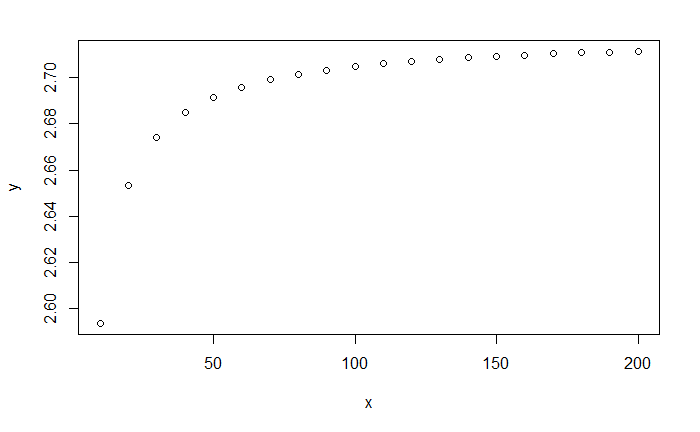

```r
plot(x, y)
```

### Missing data

in R, missing data is represented by NA.

```r
a <- NA   # assign NA to variable A
is.na(a)     # is it missing?
```

```
[1] TRUE
```

```r
a <- c(11, NA, 13)
is.na(a)
```

```
[1] FALSE  TRUE FALSE
```

```r
mean(a)
```

```
[1] NA
```

```r
mean(a, na.rm = TRUE) #NAs can be removed
```

```
[1] 12
```

### Expression and assignment

Expression is a phrase of code that can be executed.

```r
seq(10, 20, by=3)
```

```
[1] 10 13 16 19
```

```r
4
```

```
[1] 4
```

```r
mean(c(1,2,3))
```

```
[1] 2
```

```r
1 > 2
```

```
[1] FALSE
```

If the evaluation of the expression is saved using <-, then it called an assignment.

```r
x1 <- seq(10, 20, by=3)
```

```r
x2 <- 1>2
```

A logical expression is formed using * the comparison operators * <, >, <=, >=, ==, and != (not equal to) * and the logical operators * & (and), | (or), and ! (not). The value of a logical expression is either TRUE or FALSE. * The integers 1 and 0 can also be used as TRUE or FALSE.

```r
c(0, 0, 1, 1) | c(0, 1, 0, 1)
```

```
[1] FALSE  TRUE  TRUE  TRUE
```

x[subset]

We can extract a subvector using a subset as a vector of TRUE/FALSE.

```r
x <- 1:10
x%%4 == 0
```

```
 [1] FALSE FALSE FALSE  TRUE FALSE FALSE FALSE  TRUE FALSE FALSE
```

```r
( y <- x[ x%%4==0 ] )
```

```
[1] 4 8
```

R also provide subset function, which ignore NA. * whereas x[subset] preserve NA.

```r
x <- c(1, NA, 3, 4)
x[x >2]
```

```
[1] NA  3  4
```

```r
subset(x, subset = x>2 )
```

```
[1] 3 4
```

For the index position of TRUE elements, use which(x)

```r
x <- c(1, 1, 2, 3, 5, 8, 13)
which(x%%2 == 0)
```

```
[1] 3 6
```

Example : rounding error

Many floating numbers are subject to rounding errors in digital computers.

```r
2*2 == 4
```

```
[1] TRUE
```

```r
sqrt(2)*sqrt(2) == 2
```

```
[1] FALSE
```

The solution is to use all.equal(x,y), which returns TRUE if the difference between x and y is smaller than some tolerance.

```r
all.equal(sqrt(2)*sqrt(2), 2)
```

```
[1] TRUE
```

### Matrix

Matrix is created from a vector using the function matrix:

```r
matrix(data, nrow =1, ncol=1, byrow=TRUE)
```

- data : vector of length at most nrow*ncol
- if length of vector< nrow*ncol, then data is reused as many times as is needed
- nrow : number of rows
- ncol : number of columns
- byrow = TRUE : fill the matrix up row-by-row
- byrow = FALSE : fill the matrix up column-by-column, default

diag(x) : create diagonal matrix rbind(…) : join matrices with rows of the same length cbind(…) : join matrices with columns of the same length

Exampe:

```r
(A <- matrix(1:6, nrow=2, ncol=3, byrow=TRUE))
```

```
     [,1] [,2] [,3]
[1,]    1    2    3
[2,]    4    5    6
```

```r
A[1, 3] <- 0
A
```

```
     [,1] [,2] [,3]
[1,]    1    2    0
[2,]    4    5    6
```

```r
A[, 2:3]
```

```
     [,1] [,2]
[1,]    2    0
[2,]    5    6
```

```r
(B <- diag(c(1,2,3)))
```

```
     [,1] [,2] [,3]
[1,]    1    0    0
[2,]    0    2    0
[3,]    0    0    3
```

Matrix operation * Usual algebraic operations, including *, act elementwise.* To perform matrix operation, we use %*%.* nrow(x), ncol(x) * det(x) : determinant of x * t(x) : transpose of x * solve(A, B) : returns x such that A %*% x = B* If A is invertable, the solve(A) is the inverse of A.

```r
A <- matrix(c(3,5,2,3), nrow=2, ncol=2)
B <- matrix(c(1,1,0,1), nrow=2, ncol=2)
```

```r
A %*% B
```

```
     [,1] [,2]
[1,]    5    2
[2,]    8    3
```

```r
A.inv <- solve(A)
A %*% A.inv   # we observe rounding error
```

```
     [,1]                   [,2]
[1,]    1 -8.881784197001252e-16
[2,]    0  1.000000000000000e+00
```

```r
A^(-1)   #This is not an inverse. ^(-1) applies elementwise.
```

```
                   [,1]               [,2]
[1,] 0.3333333333333333 0.5000000000000000
[2,] 0.2000000000000000 0.3333333333333333
```

### Workspace

The objects that you create using R remain in existence until you explicitly delete them.

- rm(x) : remove object x
- rm(list=ls()) : remove all objects

### Working directory

When you run R, it uses one of the directories on your hard drive as a working directory, * where it looks for user-written programs and data files.

Check the working directory.

```r
getwd()
```

Change the working directory to “dir”

```r
setwd("dir")
```

/ is for directory and file address, . refers current directory, .. refers parent directory

### Writing script

We can type and evaluate all possible R expression at the prompt, it is much more convenient to write scripts, * which simply comprise collections of R expression. * We use the terms program and code synonymously with script. You can use built-in editor in Rgui or Rstudio. * or text-editor like Tinn-R, emacs

### Help

To find out more about an R command or function x, you can type help(x) or just ?x.

If you cannot remember the exact name, then help.search(“x”).

HTML help command : help.start()

### package

R provides various useful packages to help you. https://cran.r-project.org/web/packages/

To install a package:  
install.packages(“packagename”)  
To access the package:  
library(“packagename”)

Or use package menu.